# Annual Income Classifier

Wenke Huang

# 1. Introduction

## 1.1 Response variable and prediction metric

The Adult data set (URL: https://archive.ics.uci.edu/ml/datasets/Adult) that we have contains 15 variables and 32561 observations in total. The one named “salary” is our response variable. It has two levels, “>= 50K” and “<50K”, which stand for annual salary being greater than or equal to 50,000 USD or not, respectively.

The Frequency table and its corresponding Pie chart are shown below.

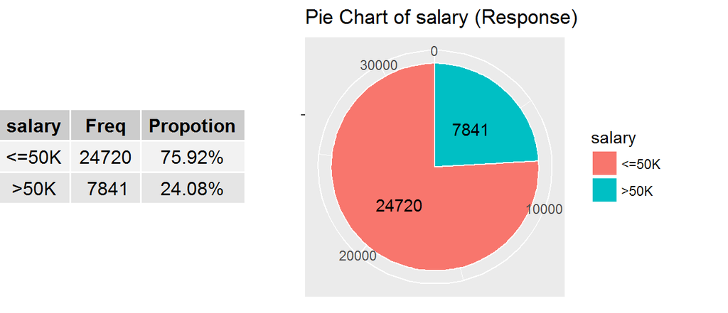

We can tell that our response variable does not follow discrete uniform distribution exactly or roughly. This may generate an obvious problem in our following model fitting part if we choose the Overall Accuracy as our metric here. Any model with Overall Accuracy being lower than 75.92% is meaningless. It is because that we can just predict that the salary is lower than or equal to 50,000 dollars, and the Overall Accuracy is going to be 75.92% exactly.

- Hence, we would like to use `ROC curve` and its corresponding `AUC` as our metric in this case.

## 1.2 Duplicate variables

Among these predictors, we notice that there are two variables which have similar names, `education` and `education_num`. We try to build a contingency table between these two variables.

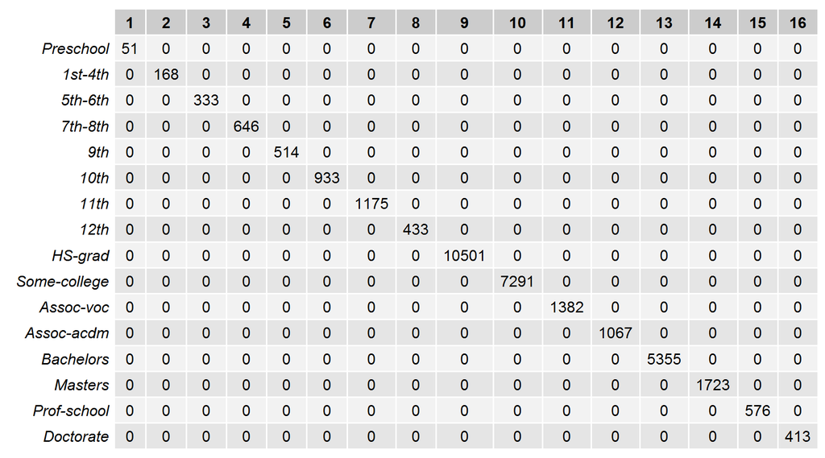

The result tells us that variable `education` and variable `education_num` are exactly one-to-one match. Even though `education_num` contains numerical values only, it still should be considered as a categorical variable like `education`. Hence, we would like to keep variable “education” only in case of the potential multicollinearity.

Further detailed information will be discussed in the following parts.

# 2 Visualization and outlier detection

## 2.1 Categorical predictor variables

In this case, apart from variable “education_num” that we have deleted already, we have 8 categorical variables. They are `workclass`, `education`, `marital_status`, `occupation`, `relationship`, `race`, `sex` and `native_country`.

### 2.1.1 Frequency bar plot

The Frequency bar plots of these 8 categorical variables are shown below to gives us a clearer understanding about univariate distributions of them visually. The frequencies of individual levels within different variables are also labeled in the plots.

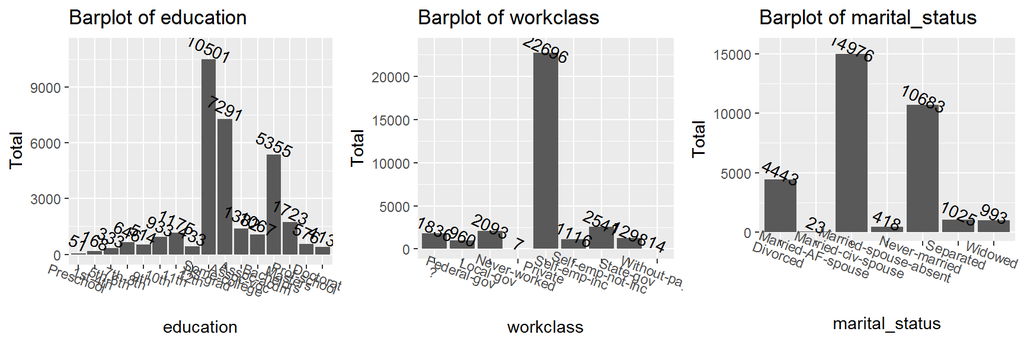

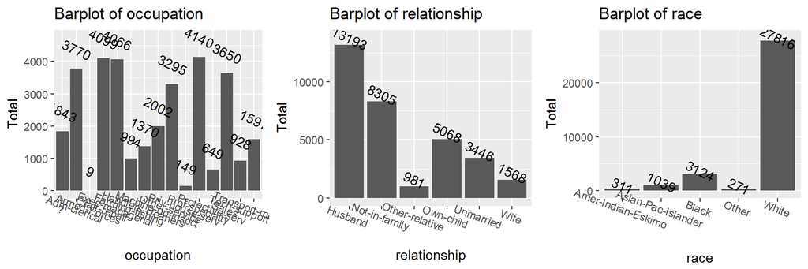

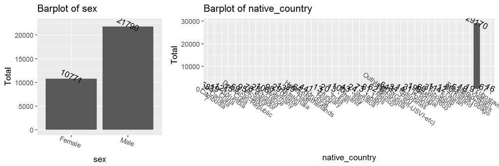

### 2.1.2 Percentage bar plot

Additionally, we would like to see what proportion of people who can earn more than 50,000 dollars are year within different categorical predictors. The Percentage bar plots of these 8 variables will also bn shown below.

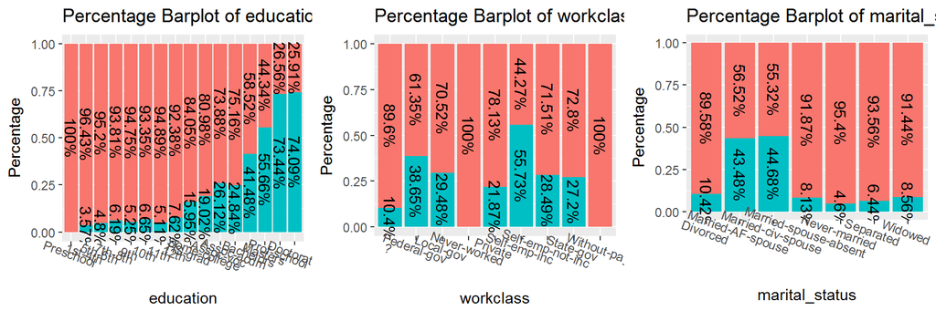

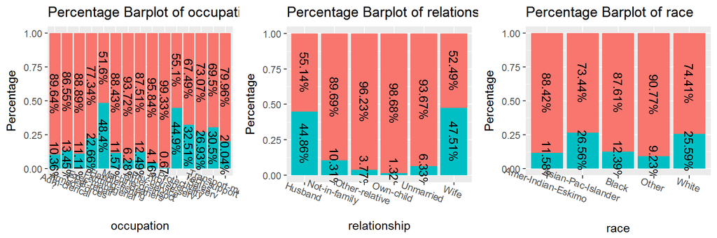

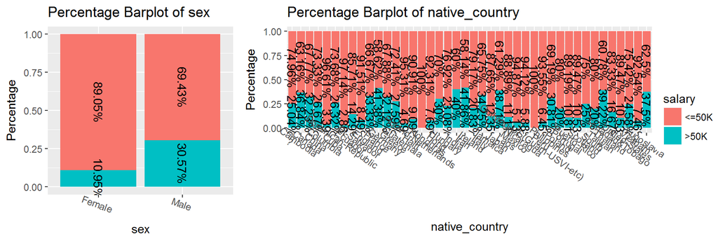

Visually speaking, the proportion of people who can make more than 50,000 dollars a year variates within different categorical variables.

Among these 8 categorical variables, variable `education` is the only one could be considered as a ordinal categorical variable while the rest 7 should be treated as nominal categorical variables. We can also notice from the first of the 8 plots that there is an interesting trend that as education level going higher towards Doctorate Degrees, the proportion of people who can make more than 50,00 dollars a year is also going up gradually.

## 2.2 Numerical variables

We have 5 numerical variables in this case. They are `age`, `capital_gain`, `capital_loss` and `hours_per_week`. As what we have discussed in he previous part, `education_num` will not be considered as one of numerical variables and visualized here even though it has numerical values.

### 2.2.1 Discrete variables

Among these 5 numerical variables, “age” and “hours_per_week” should be considered as discrete numerical variables because the all values of both variables in this dataset are integers. So we choose Histogram to visualize the univariate distribution of both of them.

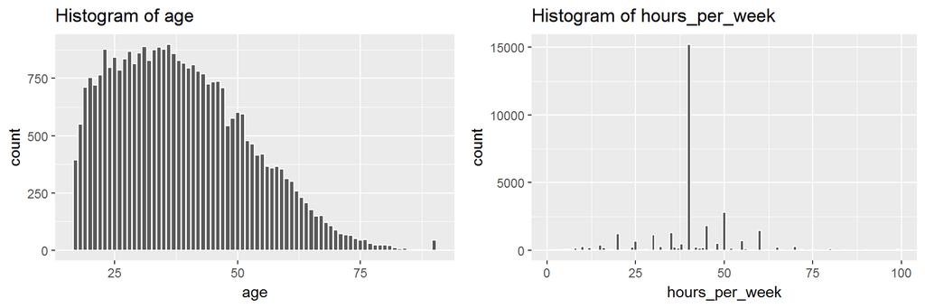

From the Histogram of “hours_per_week”, we notice that most people work exactly 40 hours a week. Also at the same time, we still can read that some people work as a part-time employee (lower than 20 hours), or do serious overtime.

### 2.2.2 Continuous variables

In this dataset, we would like to treat variables `fnlwgt`, `capital_gain` and `capital_loss` as continuous numerical variables here because of their wide ranges. Hence, the Density plot is selected here to visualize these three.

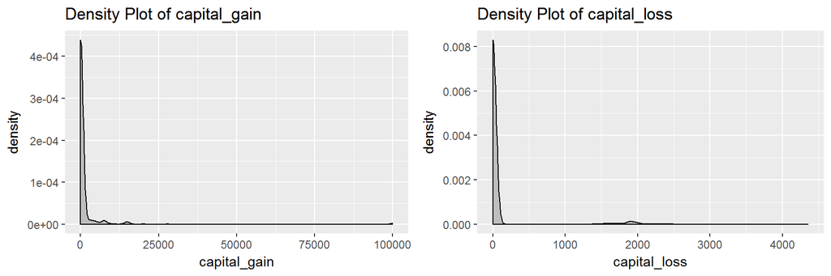

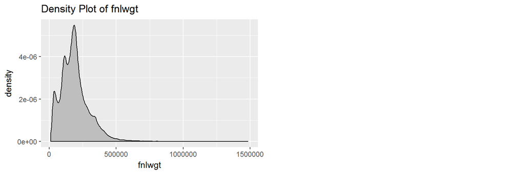

For the first two variables `capital_gain` and `capital_loss`, we notice that most of its values are 0 (91.67% and 95.33%, respectively). It shows that very few people gain or lose their money through capital ways. And all these three variables are highly skewed to the right.

### 2.2.3 Box plot and outlier detection

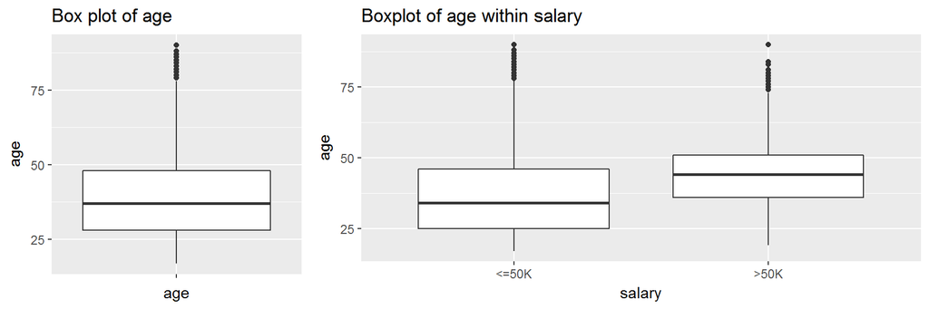

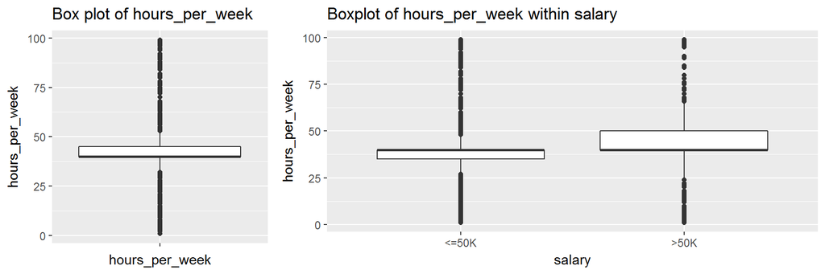

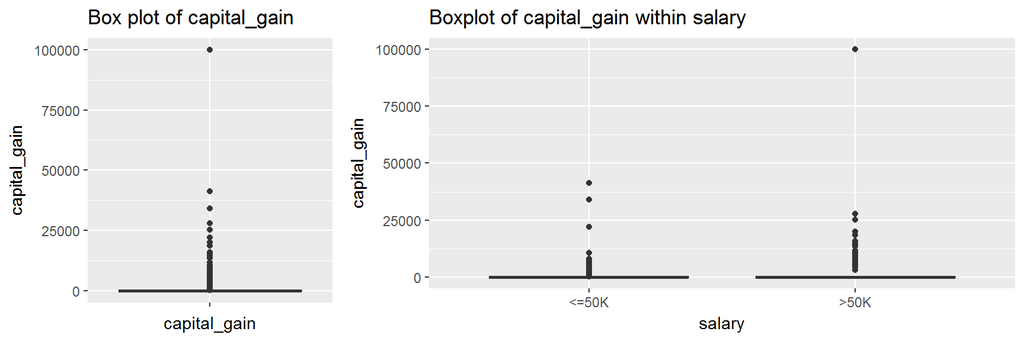

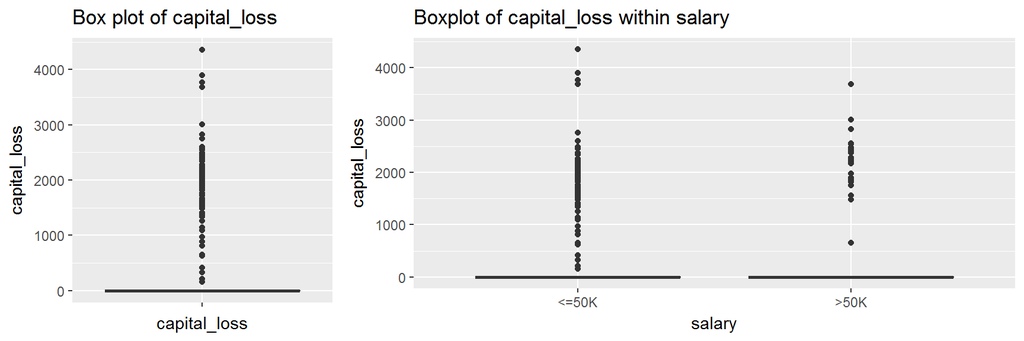

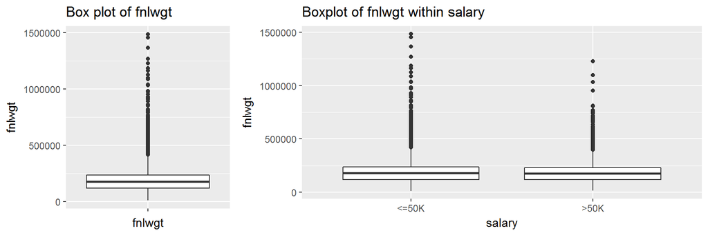

We notice that all these five numerical variables contain several points which locate out of the interval $(Q1-1.5\times IQR, Q3+1.5\times IQR)$, where Q1, Q3, and IQR stand for 25th percentile, 75th percentile and Q3-Q1, respectively. Here, we would like to treat those points as outliers.

For variables `capital_gain`, `capital_loss`, and `hours_per_week`, I would like to choose to keep those points which do not fall in the above interval. Because those observations actually stand for real things. A person with positive `capital_gain` tend to have higher incomes, which may result in being classified into a different group. Variable `capital_loss` has the same influence but in a different direction. For `hours_per_week`, people who work over time tend to make more money annually while those who work part-time tend to not get paid that much.

But for variable `age`, we have 43 observations which stand for 43 people still choose to work after their 90th birthday. These points must be resulted from typo or some other data entry mistakes.

How to deal with these points will be discussed in part `3.2`.

### 2.2.4 Correlation coefficient matrix

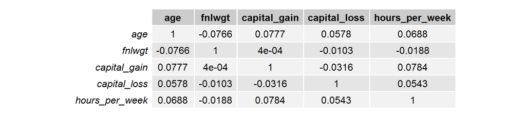

# 3 Data cleaning, outliers and dataset spliting

## 3.1 Missing values and Data cleaning

In this case, we notice that there are some observations containing logical mistakes, such as `sex` being Male but `relationship` being Wife at the same time. Part of missing records are shown as examples and listed below, and only related variables are included here.

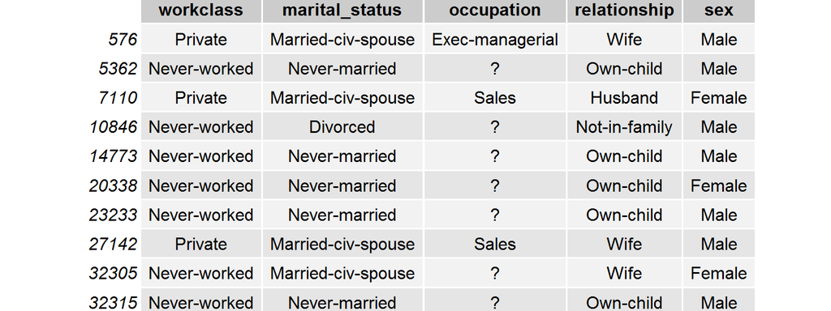

- Step 1:

For observations 576, 7110 and 27142, variable `sex` and `relationship` are obviously in conflict with each other. A person cannot be wife and male, or husband and female at the same time. There is no way for us to detect which variable value was entried correctly and which was not. Hence, we would like to discard these three observations.

- Step 2:

For the rest observations on the list, variable `occupation` is recorded as a question mark `?` because there is no corresponding level in the variable `workclass`. Hence we would like to add a new level `Unemployed` and change these question marks `?` into it.

- Step 3:

After correcting those points, we notice that the rest question mark `?` values in predictors `occupation` and `workclass` are exactly one-to-one match. It means that if we find variable `occupation` of one observation is recorded as `?`, `workclass` of the same observation is recorded as `?`, too. And if we find variable `occupation` of one observation is not recorded as `?`, `workclass` of the same observation is not `?`, either. Hence, we would like to treat the these question marks as a new level `other`.

- Step 4:

Variable `native_country` still contains question mark `?`. Here, we cannot find a proper way for us to correct those observations. Here, we would like to impute those missing values. Decision tree is used here.

## 3.2 Dataset spliting and Outliers

Here, we would like to split our datasets into training and testing sets. We will use training datasets only to fit our statistical models, and both training and testing prediction will be used to validated our models. Like we discussed in the previous part, we would like to have two dataets, one being the original full set while the other one being the subset without outliers.

Here, for variable `fnlwgt`, `capital_gain`, `capital_loss`, and `hours_per_week`, we would like to keep the outliers because those points actually stand for some real world issues here. Pairwise deleting may cause serious problems and make our models less trustable.

However, for `age`, we would like to do pairwise delete all observations with `age` value being greater han or equal to 78. 78 is the upper bound of interval $(Q1-1.5\times IQR, Q3+1.5\times IQR)$, and there is no value less than the lower bound of this interval.

## 3.3 Feature selection

We would like to use variable importance from `Random Forest` here to help us select the features that we will include in our models. Both original datasets and datasets without outliers will be calculated here. We visualize the quantitive output in the following graphs.

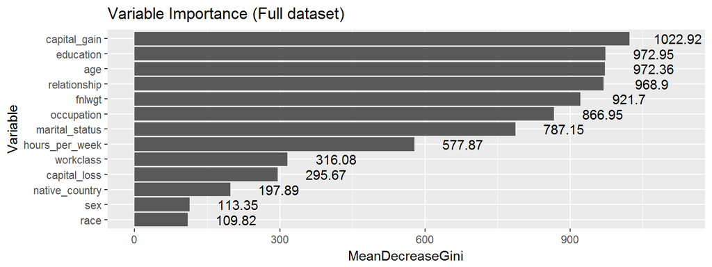

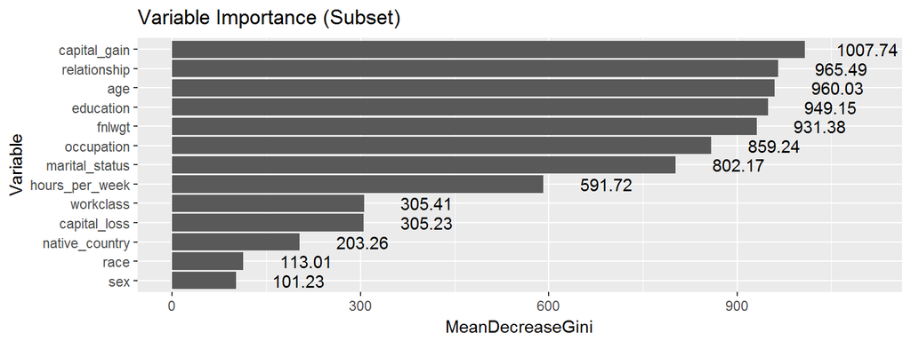

From both graphs, we can read that the results of our two models are basically the same as each other. Based on the result, we would like to keep `capital_gain`, `education`, `relationship`, `age`, `fnlwgt`, `occupation` and `marital_status` into our final models as our predictors.

Additionaly, for logistic regression models, backward elimination will also be applied in case of insignificant predictors being existing.

# 4 Model fitting and Prediction

In this part, the five algorithms that we are about to use are `Logistic Regression`, `CART`, `Naive Bayes`, `Bagging` and `Random Forest`. For each algorithm, we would like to build at least two models. One is based on training set obtained from the full dataset, and the other one is from the training set obtained from the dataset without outliers.

## 4.1 Logistic regression

### 4.1.1 Model with full dataset

First we would like to build a Logistic Regression by using training dataset obtained from original dataset (without removing outliers).

```
##
## Call:
## glm(formula = salary_num ~ relationship + capital_gain + age +
##     education + occupation + marital_status + fnlwgt, family = binomial(link = "logit"),
##     data = Train_Adult)
##
## Deviance Residuals:
##     Min       1Q   Median       3Q      Max
## -5.0324  -0.5407  -0.2073  -0.0384   3.6972
##
## Coefficients:
##                                       Estimate Std. Error z value Pr(>|z|)
## (Intercept)                         -2.370e+01  1.037e+02  -0.228   0.8193
## relationshipNot-in-family            4.933e-02  2.929e-01   0.168   0.8663
## relationshipOther-relative          -1.064e+00  2.643e-01  -4.027 5.65e-05
## relationshipOwn-child               -1.356e+00  2.925e-01  -4.638 3.52e-06
## relationshipUnmarried               -3.751e-01  3.068e-01  -1.223   0.2214
## relationshipWife                     3.383e-01  7.429e-02   4.554 5.27e-06
## capital_gain                         3.079e-04  1.120e-05  27.476  < 2e-16
## age                                  2.096e-02  1.727e-03  12.137  < 2e-16
## education1st-4th                     1.806e+01  1.037e+02   0.174   0.8618
## education5th-6th                     1.849e+01  1.037e+02   0.178   0.8585
## education7th-8th                     1.833e+01  1.037e+02   0.177   0.8598
## education9th                         1.856e+01  1.037e+02   0.179   0.8580
## education10th                        1.880e+01  1.037e+02   0.181   0.8562
## education11th                        1.875e+01  1.037e+02   0.181   0.8565
## education12th                        1.924e+01  1.037e+02   0.185   0.8528
## educationHS-grad                     1.959e+01  1.037e+02   0.189   0.8502
## educationSome-college                1.996e+01  1.037e+02   0.192   0.8474
## educationAssoc-voc                   2.016e+01  1.037e+02   0.194   0.8459
## educationAssoc-acdm                  2.011e+01  1.037e+02   0.194   0.8463
## educationBachelors                   2.080e+01  1.037e+02   0.201   0.8410
## educationMasters                     2.110e+01  1.037e+02   0.203   0.8388
## educationProf-school                 2.175e+01  1.037e+02   0.210   0.8339
## educationDoctorate                   2.187e+01  1.037e+02   0.211   0.8330
## occupationArmed-Forces              -1.151e+01  2.903e+02  -0.040   0.9684
## occupationCraft-repair               1.914e-01  8.495e-02   2.253   0.0242
## occupationExec-managerial            9.068e-01  8.099e-02  11.196  < 2e-16
## occupationFarming-fishing           -9.073e-01  1.499e-01  -6.053 1.43e-09
## occupationHandlers-cleaners         -6.402e-01  1.559e-01  -4.106 4.03e-05
```

[output cut: 58 more lines]

```
## marital_statusMarried-spouse-absent
## marital_statusNever-married         ***
## marital_statusSeparated
## marital_statusWidowed
## fnlwgt                              *
## ---
## Signif. codes:  0 '***' 0.001 '**' 0.01 '*' 0.05 '.' 0.1 ' ' 1
##
## (Dispersion parameter for binomial family taken to be 1)
##
##     Null deviance: 28853  on 26045  degrees of freedom
## Residual deviance: 17331  on 26001  degrees of freedom
## AIC: 17421
##
## Number of Fisher Scoring iterations: 13
```

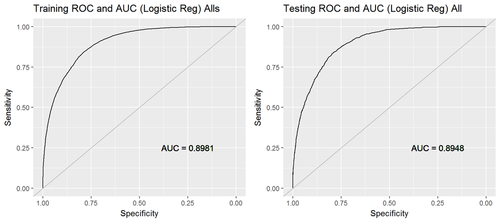

The predictions are also made here. We notice that `education` is not significant here. We will build another model without considerding `education` as one predictor.

```
##
## Call:
## glm(formula = salary_num ~ relationship + capital_gain + age +
##     occupation + marital_status + fnlwgt, family = binomial(link = "logit"),
##     data = Train_Adult)
##
## Deviance Residuals:
##     Min       1Q   Median       3Q      Max
## -4.7059  -0.5805  -0.2286  -0.0631   3.5056
##
## Coefficients:
##                                       Estimate Std. Error z value Pr(>|z|)
## (Intercept)                         -3.451e+00  3.135e-01 -11.011  < 2e-16
## relationshipNot-in-family            4.860e-02  2.876e-01   0.169 0.865809
## relationshipOther-relative          -1.280e+00  2.625e-01  -4.879 1.07e-06
## relationshipOwn-child               -1.559e+00  2.875e-01  -5.421 5.93e-08
## relationshipUnmarried               -4.740e-01  3.011e-01  -1.574 0.115411
## relationshipWife                     1.950e-01  7.196e-02   2.709 0.006748
## capital_gain                         3.047e-04  1.072e-05  28.433  < 2e-16
## age                                  1.758e-02  1.630e-03  10.783  < 2e-16
## occupationArmed-Forces              -1.100e+01  1.732e+02  -0.064 0.949349
## occupationCraft-repair              -1.505e-01  8.160e-02  -1.845 0.065058
## occupationExec-managerial            1.183e+00  7.777e-02  15.217  < 2e-16
## occupationFarming-fishing           -1.239e+00  1.460e-01  -8.488  < 2e-16
## occupationHandlers-cleaners         -1.088e+00  1.515e-01  -7.180 6.98e-13
## occupationMachine-op-inspct         -6.440e-01  1.047e-01  -6.152 7.66e-10
## occupationOther                     -9.175e-01  1.210e-01  -7.584 3.36e-14
## occupationOther-service             -1.203e+00  1.214e-01  -9.911  < 2e-16
## occupationPriv-house-serv           -3.529e+00  1.384e+00  -2.551 0.010740
## occupationProf-specialty             1.307e+00  7.809e-02  16.735  < 2e-16
## occupationProtective-serv            4.987e-01  1.293e-01   3.856 0.000115
## occupationSales                      4.713e-01  8.295e-02   5.682 1.33e-08
## occupationTech-support               9.276e-01  1.165e-01   7.963 1.68e-15
## occupationTransport-moving          -3.524e-01  1.027e-01  -3.432 0.000600
## occupationUnemployed                -1.091e+01  1.869e+02  -0.058 0.953422
## marital_statusMarried-AF-spouse      2.813e+00  6.389e-01   4.403 1.07e-05
## marital_statusMarried-civ-spouse     1.982e+00  2.918e-01   6.793 1.10e-11
## marital_statusMarried-spouse-absent  9.364e-02  2.356e-01   0.397 0.691071
## marital_statusNever-married         -3.537e-01  9.205e-02  -3.843 0.000122
## marital_statusSeparated             -1.157e-01  1.735e-01  -0.667 0.504864
```

[output cut: 28 more lines]

```
## marital_statusMarried-spouse-absent
## marital_statusNever-married         ***
## marital_statusSeparated
## marital_statusWidowed               *
## fnlwgt                              .
## ---
## Signif. codes:  0 '***' 0.001 '**' 0.01 '*' 0.05 '.' 0.1 ' ' 1
##
## (Dispersion parameter for binomial family taken to be 1)
##
##     Null deviance: 28853  on 26045  degrees of freedom
## Residual deviance: 18392  on 26016  degrees of freedom
## AIC: 18452
##
## Number of Fisher Scoring iterations: 12
```

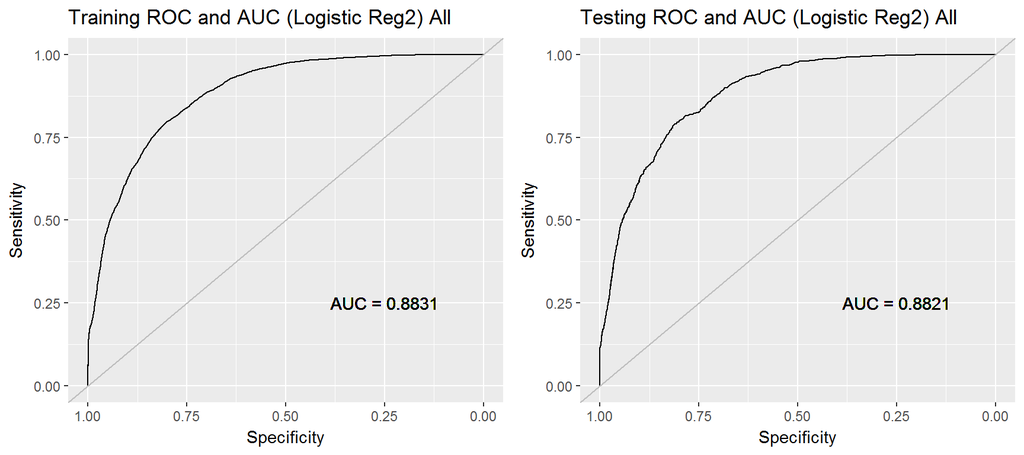

### 4.1.2 Model with subset (Without outliers)

Then, we would like to fit the model by using dataset without outliers.

```
##
## Call:
## glm(formula = salary_num ~ relationship + capital_gain + age +
##     education + occupation + marital_status + fnlwgt, family = binomial(link = "logit"),
##     data = Train_Adult1)
##
## Deviance Residuals:
##     Min       1Q   Median       3Q      Max
## -5.0191  -0.5432  -0.2079  -0.0403   3.6554
##
## Coefficients:
##                                       Estimate Std. Error z value Pr(>|z|)
## (Intercept)                         -2.408e+01  1.106e+02  -0.218  0.82760
## relationshipNot-in-family            1.648e-01  2.882e-01   0.572  0.56736
## relationshipOther-relative          -9.192e-01  2.645e-01  -3.475  0.00051
## relationshipOwn-child               -1.246e+00  2.875e-01  -4.334 1.47e-05
## relationshipUnmarried               -2.571e-01  3.027e-01  -0.850  0.39560
## relationshipWife                     3.650e-01  7.394e-02   4.936 7.97e-07
## capital_gain                         3.022e-04  1.099e-05  27.505  < 2e-16
## age                                  2.145e-02  1.726e-03  12.427  < 2e-16
## education1st-4th                     1.833e+01  1.106e+02   0.166  0.86835
## education5th-6th                     1.881e+01  1.106e+02   0.170  0.86488
## education7th-8th                     1.835e+01  1.106e+02   0.166  0.86816
## education9th                         1.855e+01  1.106e+02   0.168  0.86672
## education10th                        1.902e+01  1.106e+02   0.172  0.86342
## education11th                        1.912e+01  1.106e+02   0.173  0.86272
## education12th                        1.934e+01  1.106e+02   0.175  0.86111
## educationHS-grad                     1.977e+01  1.106e+02   0.179  0.85810
## educationSome-college                2.016e+01  1.106e+02   0.182  0.85533
## educationAssoc-voc                   2.034e+01  1.106e+02   0.184  0.85399
## educationAssoc-acdm                  2.032e+01  1.106e+02   0.184  0.85414
## educationBachelors                   2.095e+01  1.106e+02   0.189  0.84974
## educationMasters                     2.127e+01  1.106e+02   0.192  0.84744
## educationProf-school                 2.193e+01  1.106e+02   0.198  0.84278
## educationDoctorate                   2.205e+01  1.106e+02   0.199  0.84189
## occupationArmed-Forces               4.437e-02  1.343e+00   0.033  0.97365
## occupationCraft-repair               1.869e-01  8.482e-02   2.203  0.02758
## occupationExec-managerial            9.351e-01  8.111e-02  11.529  < 2e-16
## occupationFarming-fishing           -7.416e-01  1.453e-01  -5.105 3.30e-07
## occupationHandlers-cleaners         -6.113e-01  1.534e-01  -3.986 6.72e-05
```

[output cut: 58 more lines]

```
## marital_statusMarried-spouse-absent
## marital_statusNever-married         ***
## marital_statusSeparated
## marital_statusWidowed
## fnlwgt                              **
## ---
## Signif. codes:  0 '***' 0.001 '**' 0.01 '*' 0.05 '.' 0.1 ' ' 1
##
## (Dispersion parameter for binomial family taken to be 1)
##
##     Null deviance: 28773  on 26102  degrees of freedom
## Residual deviance: 17339  on 26058  degrees of freedom
## AIC: 17429
##
## Number of Fisher Scoring iterations: 13
```

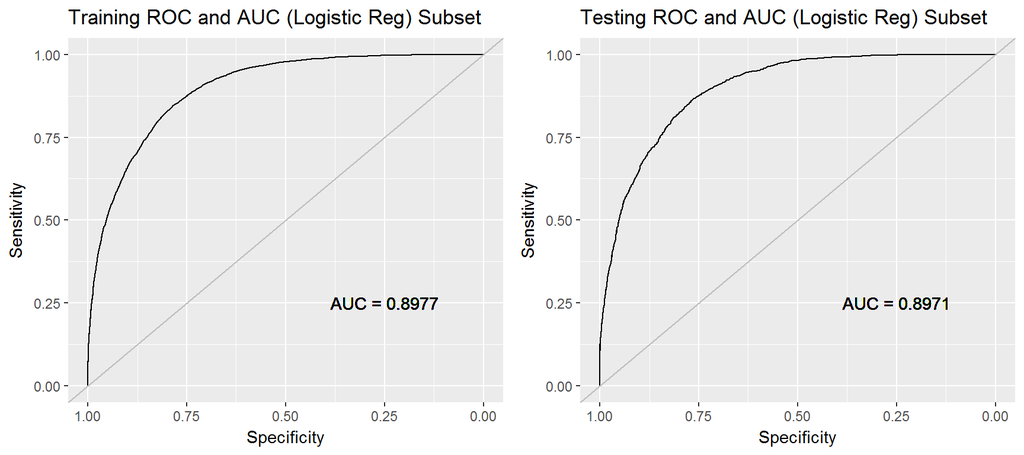

In the second model, we are facing the same problem that `education` is not statistically significant in our model. Like the previous part, we would like to fit another model without `education` variable.

```
##
## Call:
## glm(formula = salary_num ~ relationship + capital_gain + age +
##     occupation + marital_status + fnlwgt, family = binomial(link = "logit"),
##     data = Train_Adult1)
##
## Deviance Residuals:
##     Min       1Q   Median       3Q      Max
## -4.7181  -0.5846  -0.2296  -0.0618   3.5258
##
## Coefficients:
##                                       Estimate Std. Error z value Pr(>|z|)
## (Intercept)                         -3.681e+00  3.102e-01 -11.866  < 2e-16
## relationshipNot-in-family            1.763e-01  2.839e-01   0.621 0.534663
## relationshipOther-relative          -1.147e+00  2.646e-01  -4.335 1.46e-05
## relationshipOwn-child               -1.434e+00  2.829e-01  -5.070 3.98e-07
## relationshipUnmarried               -3.344e-01  2.979e-01  -1.122 0.261714
## relationshipWife                     2.245e-01  7.184e-02   3.125 0.001778
## capital_gain                         3.017e-04  1.055e-05  28.603  < 2e-16
## age                                  1.813e-02  1.635e-03  11.092  < 2e-16
## occupationArmed-Forces               1.459e-01  1.187e+00   0.123 0.902175
## occupationCraft-repair              -1.480e-01  8.165e-02  -1.813 0.069858
## occupationExec-managerial            1.213e+00  7.801e-02  15.550  < 2e-16
## occupationFarming-fishing           -1.053e+00  1.409e-01  -7.473 7.84e-14
## occupationHandlers-cleaners         -1.050e+00  1.488e-01  -7.052 1.76e-12
## occupationMachine-op-inspct         -6.265e-01  1.054e-01  -5.943 2.80e-09
## occupationOther                     -8.721e-01  1.198e-01  -7.281 3.30e-13
## occupationOther-service             -1.216e+00  1.226e-01  -9.918  < 2e-16
## occupationPriv-house-serv           -3.606e+00  1.338e+00  -2.694 0.007056
## occupationProf-specialty             1.353e+00  7.812e-02  17.314  < 2e-16
## occupationProtective-serv            4.989e-01  1.282e-01   3.893 9.89e-05
## occupationSales                      4.905e-01  8.316e-02   5.898 3.67e-09
## occupationTech-support               8.783e-01  1.157e-01   7.589 3.23e-14
## occupationTransport-moving          -3.375e-01  1.025e-01  -3.292 0.000994
## occupationUnemployed                -1.016e+01  1.358e+02  -0.075 0.940388
## marital_statusMarried-AF-spouse      2.528e+00  5.891e-01   4.292 1.77e-05
## marital_statusMarried-civ-spouse     2.124e+00  2.885e-01   7.363 1.80e-13
## marital_statusMarried-spouse-absent  2.977e-02  2.403e-01   0.124 0.901387
## marital_statusNever-married         -3.410e-01  9.282e-02  -3.674 0.000239
## marital_statusSeparated             -1.965e-01  1.769e-01  -1.111 0.266554
```

[output cut: 28 more lines]

```
## marital_statusMarried-spouse-absent
## marital_statusNever-married         ***
## marital_statusSeparated
## marital_statusWidowed
## fnlwgt                              **
## ---
## Signif. codes:  0 '***' 0.001 '**' 0.01 '*' 0.05 '.' 0.1 ' ' 1
##
## (Dispersion parameter for binomial family taken to be 1)
##
##     Null deviance: 28773  on 26102  degrees of freedom
## Residual deviance: 18360  on 26073  degrees of freedom
## AIC: 18420
##
## Number of Fisher Scoring iterations: 11
```

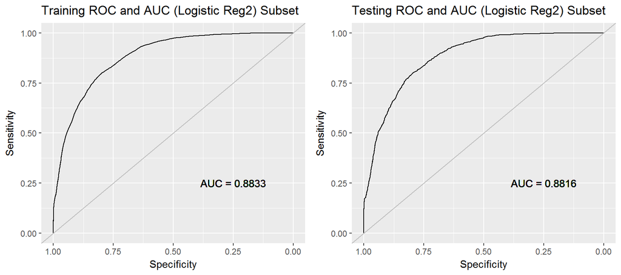

### 4.1.3 Summary of Logistic Regression

We notice that for both of the datasets, we built two models. The first one is based on all predictors selected from Random Forest, and the second one is based on the result of the first one.

Hence, in this case, I still would like to keep first model of both parts as our final models of this algorithm since their AICs and AUCs are better.

## 4.2 Classification and Regression Tree

### 4.2.1 Model with full dataset

Here, we would like to build a CART model by using training dataset obtained from original dataset (without removing outliers).

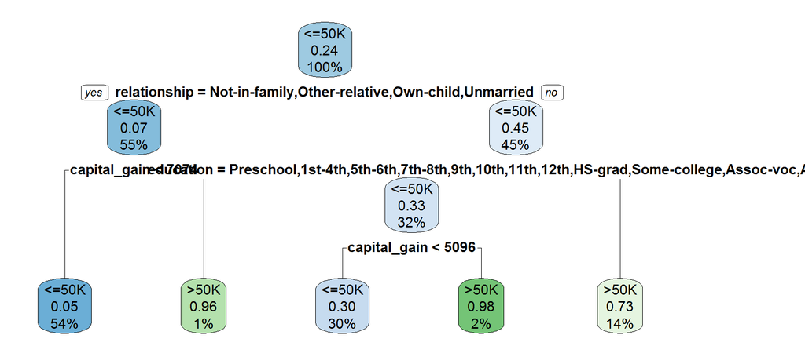

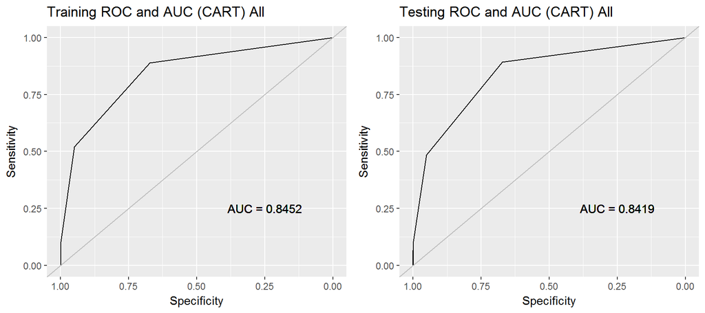

### 4.2.2 Model with subset (Without outliers)

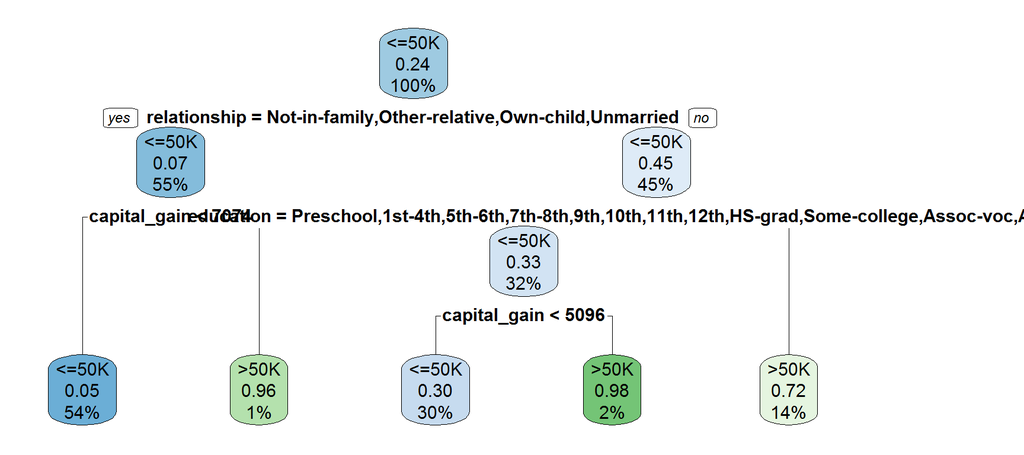

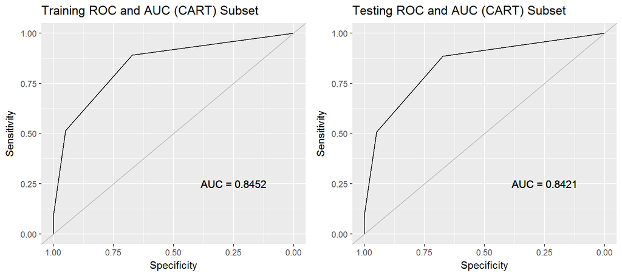

### 4.2.3 Summary of CART

We noticed from the tree plot and ROC curves that these two models are slightly different with each other. This also shows us one of weakness which is its sensitivity. The model may change dramatically by removing or adding observations. Here, we only removed very few of the total observations, which does not result in significant variation.

Bagging and Random Forest models will also be attempt later.

## 4.3 Naive Bayes classifier

### 4.3.1 Model with full dataset

Firstly, we would like to build a Naive Bayes model by using training dataset obtained from original dataset (without removing outliers). The summary of this model and the training and testing ROC curves and AUCs are also shown below.

```
##
## Naive Bayes Classifier for Discrete Predictors
##
## Call:
## naiveBayes.default(x = X, y = Y, laplace = laplace)
##
## A-priori probabilities:
## Y
##     <=50K      >50K
## 0.7575443 0.2424557
##
## Conditional probabilities:
##        relationship
## Y           Husband Not-in-family Other-relative   Own-child   Unmarried
##   <=50K 0.294967310   0.300086159    0.038011251 0.205311439 0.129086210
##   >50K  0.754711006   0.109263658    0.004592241 0.008551069 0.028503563
##        relationship
## Y              Wife
##   <=50K 0.032537631
##   >50K  0.094378464
##
##        capital_gain
## Y            [,1]      [,2]
##   <=50K  146.5552  1005.488
##   >50K  4059.0163 14719.714
##
##        age
## Y           [,1]     [,2]
##   <=50K 36.77269 14.06292
##   >50K  44.29264 10.55898
##
##        education
## Y          Preschool      1st-4th      5th-6th      7th-8th          9th
##   <=50K 0.0017738584 0.0064365719 0.0130758705 0.0256449242 0.0199178957
##   >50K  0.0000000000 0.0006334125 0.0022169438 0.0058590657 0.0039588282
##        education
## Y               10th         11th         12th      HS-grad Some-college
##   <=50K 0.0352744412 0.0443971416 0.0166742689 0.3556839491 0.2404845168
##   >50K  0.0079176564 0.0072842439 0.0042755344 0.2091844814 0.1745051465
##        education
```

[output cut: 23 more lines]

```
##   >50K  0.1266825020 0.0367379256     0.0397466350 0.0000000000
##
##        marital_status
## Y           Divorced Married-AF-spouse Married-civ-spouse
##   <=50K 0.1608636156      0.0004054533       0.3354619634
##   >50K  0.0592240697      0.0012668250       0.8522565321
##        marital_status
## Y       Married-spouse-absent Never-married    Separated      Widowed
##   <=50K          0.0151031372  0.4140692312 0.0376564797 0.0364401196
##   >50K           0.0047505938  0.0636579572 0.0079176564 0.0109263658
##
##        fnlwgt
## Y           [,1]     [,2]
##   <=50K 190813.3 107226.4
##   >50K  187896.0 103360.2
```

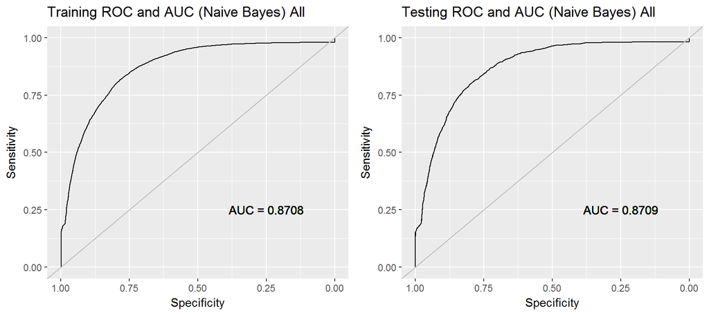

### 4.3.2 Model with subset (Without outliers)

Then, we would like to build another Naive Bayes model by using training dataset obtained from dataset (after removing outliers). The summary of this model and the training and testing ROC curves and AUCs are also shown below, as well.

```
##
## Naive Bayes Classifier for Discrete Predictors
##
## Call:
## naiveBayes.default(x = X, y = Y, laplace = laplace)
##
## A-priori probabilities:
## Y
##    <=50K     >50K
## 0.759951 0.240049
##
## Conditional probabilities:
##        relationship
## Y          Husband Not-in-family Other-relative  Own-child  Unmarried
##   <=50K 0.29480264    0.30065030     0.03806019 0.20365983 0.12980793
##   >50K  0.75359081    0.10916055     0.00446856 0.00877753 0.02792850
##        relationship
## Y             Wife
##   <=50K 0.03301911
##   >50K  0.09607405
##
##        capital_gain
## Y            [,1]      [,2]
##   <=50K  152.2676  1012.858
##   >50K  4102.7933 14957.907
##
##        age
## Y           [,1]     [,2]
##   <=50K 36.74366 14.05225
##   >50K  44.17028 10.50472
##
##        education
## Y          Preschool      1st-4th      5th-6th      7th-8th          9th
##   <=50K 0.0022180773 0.0062509452 0.0128043555 0.0239451530 0.0197610526
##   >50K  0.0000000000 0.0007979572 0.0025534631 0.0046281519 0.0031918289
##        education
## Y               10th         11th         12th      HS-grad Some-college
##   <=50K 0.0356404698 0.0466804456 0.0161314715 0.3560518224 0.2393507083
##   >50K  0.0084583466 0.0084583466 0.0041493776 0.2090647941 0.1784232365
##        education
```

[output cut: 23 more lines]

```
##   >50K  0.1243217364 0.0360676668     0.0403766358 0.0000000000
##
##        marital_status
## Y           Divorced Married-AF-spouse Married-civ-spouse
##   <=50K 0.1578867772      0.0006049302       0.3351313203
##   >50K  0.0571337376      0.0011171401       0.8531758698
##        marital_status
## Y       Married-spouse-absent Never-married    Separated      Widowed
##   <=50K          0.0160306498  0.4141755306 0.0384130665 0.0377577255
##   >50K           0.0044685605  0.0643153527 0.0084583466 0.0113309927
##
##        fnlwgt
## Y           [,1]     [,2]
##   <=50K 190141.8 106593.1
##   >50K  188371.8 103027.8
```

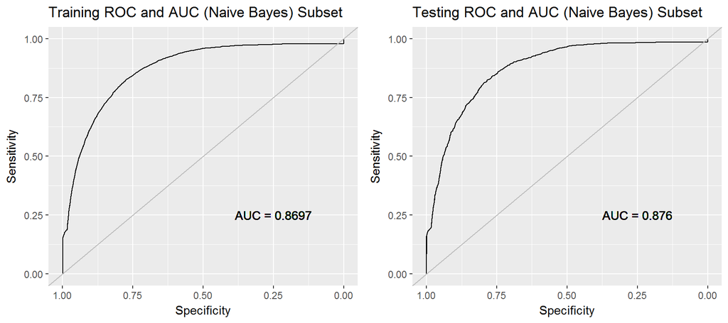

### 4.3.3 Summary of Naive Bayes

We know that `Naive Bayes` algorithm is based on the Bayes theory with strong independence assumptions between different predictors. In this case, we have tested the correlationship between different numerical variable. However, we did not test that between categorical variables or categorical and numerical variables. This may result in not well model performances.

## 4.4 Bagging

### 4.4.1 Model with full dataset

Firstly, we would like to build a `Bagging` model by using training dataset obtained from original dataset (without removing outliers). The training and testing ROC curves and AUCs are also shown below.

Unlike the previous three models, we only include very brief model information here. Because in `Bagging`, we will build many models, and then take the majority vote because this is a classification model.

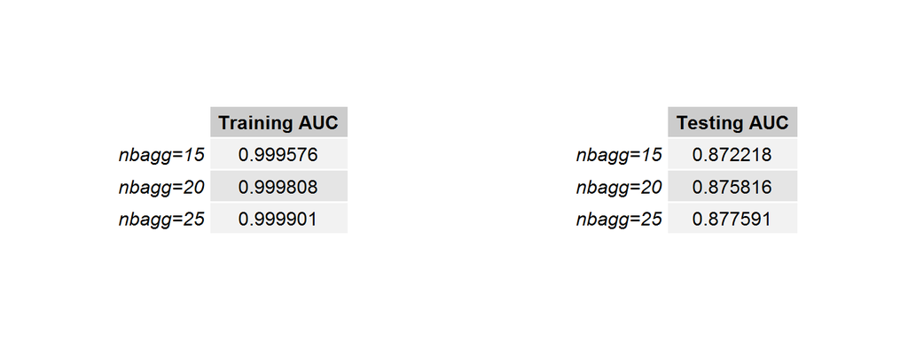

Hence, we would like to choose `nbagg = 25` as our final parameters since it has the highest testing AUC. The detailed information about this model will be listed below.

```
##
## Bagging classification trees with 25 bootstrap replications
##
## Call: bagging.data.frame(formula = salary ~ relationship + capital_gain +
##     age + education + occupation + marital_status + fnlwgt, data = Train_Adult,
##     nbagg = 25)
```

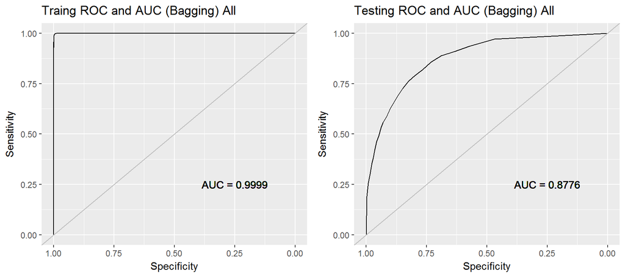